# Dietary Survival Analysis

## Dietary Data Set Analysis

In order to assess how the dietary variables from our data set impact the development of diabetes, we will conduct a survival analysis. The cleaned data has been merged with the concurrent diabetes data to form a new data frame for analysis. In the next few cells, this data frame is read and processed to prepare it for survival analysis. Categorical variables are ready for analysis. A list of these is created. Continuous variables are also put into a list, as these will require slightly more processing for the survival analysis to be conducted.

```
  respondent_sequence_num ever_breastfed_or_fed_breastmilk
1                  109263                                1
2                  109264                               NA
3                  109265                               NA
4                  109266                               NA
5                  109267                               NA
6                  109268                               NA
  age_stopped_breastfeeding_days diet_healthiness
1                   5.397605e-79               NA
2                             NA               NA
3                             NA               NA
4                             NA                3
5                             NA                1
6                             NA                3
  community_government_meals_delivered eat_meals_at_community_senior_center
```

[output cut: 41 more lines]

```
  respondent_sequence_num ever_breastfed_or_fed_breastmilk
1                  109263                                1
2                  109264                               NA
3                  109265                               NA
4                  109266                               NA
5                  109267                               NA
6                  109268                               NA
  age_stopped_breastfeeding_days diet_healthiness
1                   5.397605e-79               NA
2                             NA               NA
3                             NA               NA
4                             NA                3
5                             NA                1
6                             NA                3
  community_government_meals_delivered eat_meals_at_community_senior_center
```

[output cut: 41 more lines]

In the subsequent step, Kaplan-Meier survival curves were generated for each categorical variable in the dataset. The p-values associated with each variable, derived from log-rank tests, were annotated on the visualizations to evaluate the statistical significance of the relationship between the categorical variable and survival time.

Among the categorical variables analyzed, diet healthiness and provision of community meals by the governemnt demonstrated the most statistically significant associations with survival time, yielding a p-values of p < 0.001. These results suggest that the observed differences in survival distributions across dietary healthiness groups and communities that are provided with government meals are unlikely to occur by random chance, providing strong evidence for a relationship between these factors and the development of diabetes. Whether schools served lunches or not also had a significant effect of p = 0.002. Finally, education Thad a significant albeid moderate p value of p = o.042. This analysis suggests that the aforementioned variables may be risk factors for the development of diabetes.

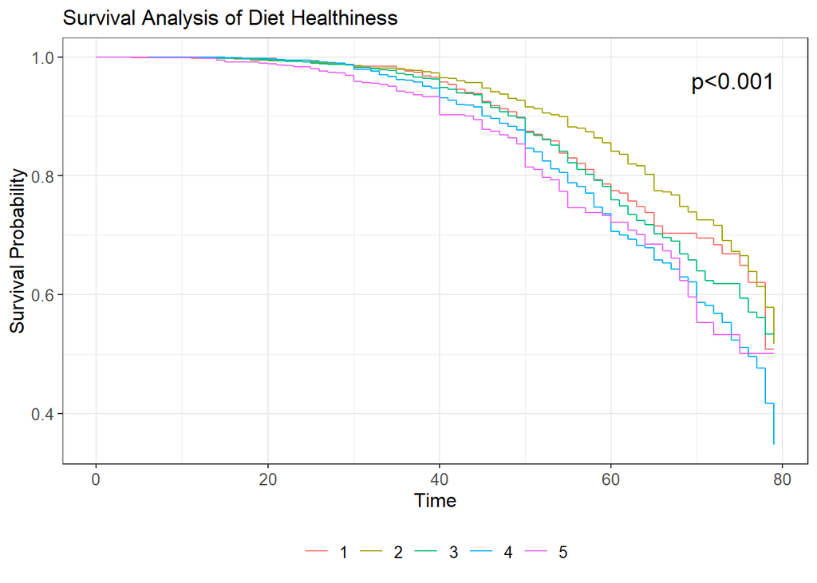

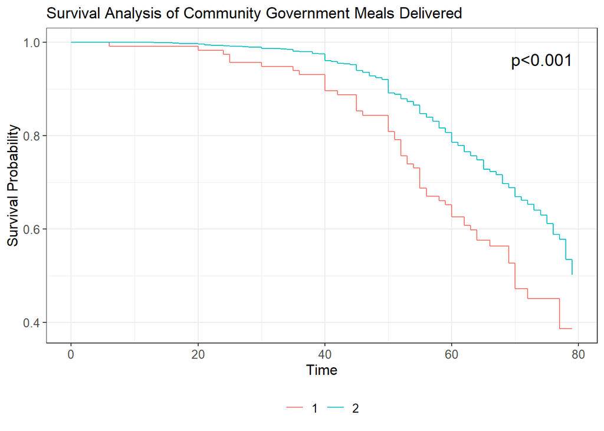

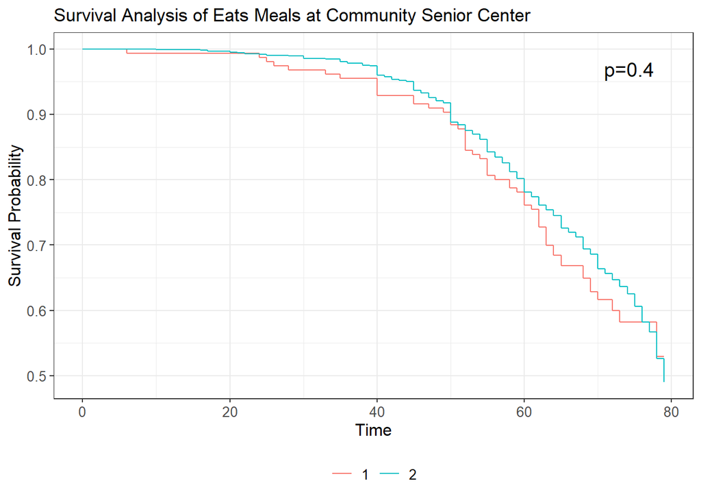

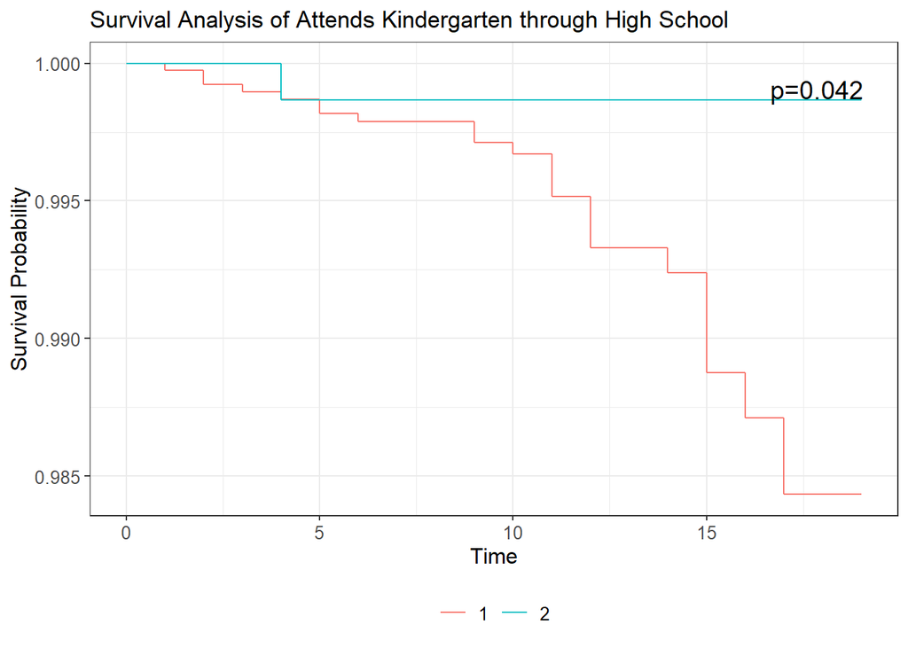

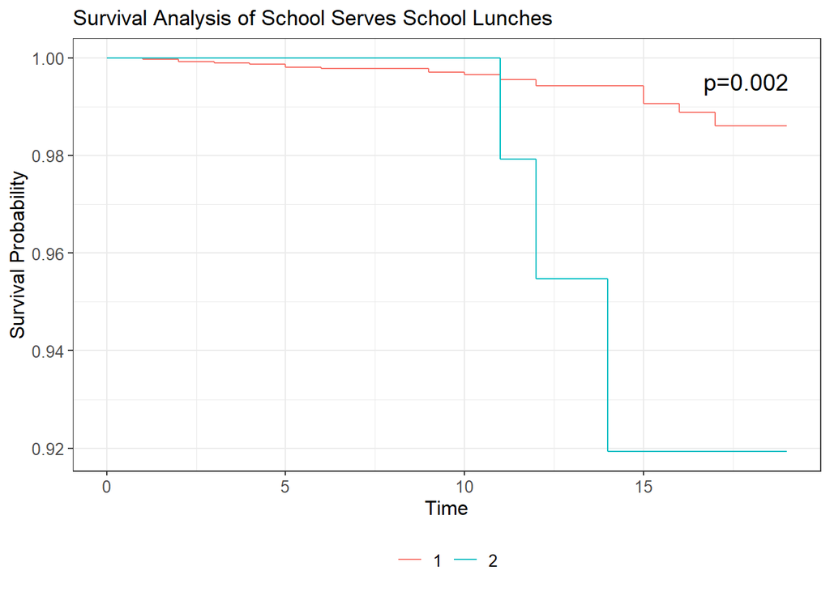

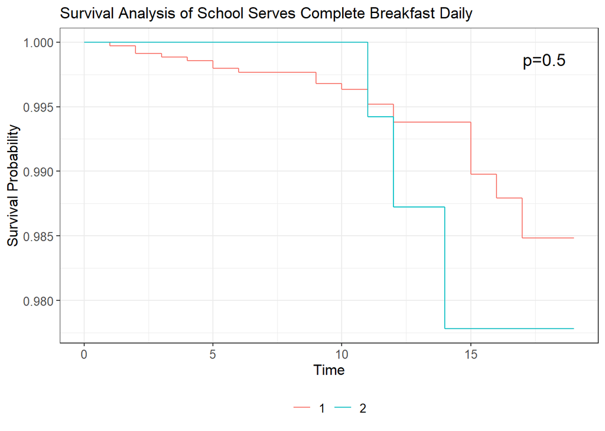

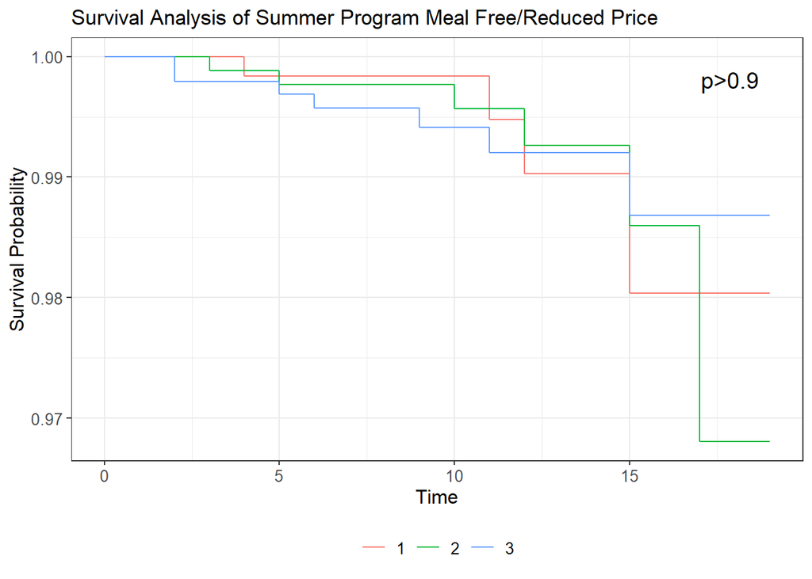

Continuous variables were analyzed similarly by first transforming them into ‘categorical’ variables. This was achieved through binning, where each continuous variable was divided into five equally sized buckets (quintiles). The binning process allows for the application of survival analysis methods, which are designed for categorical predictors. This approach provides a practical way to assess the relationship between continuous variables and survival outcomes while preserving interpretability.

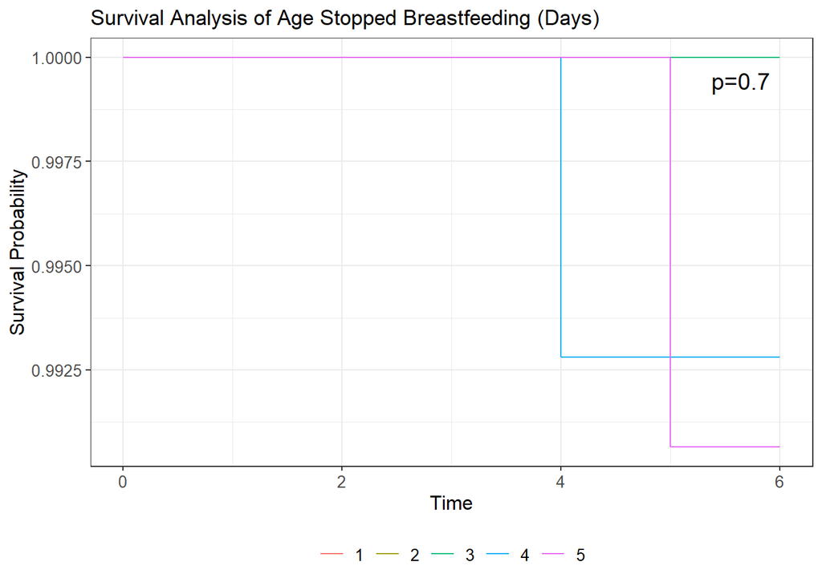

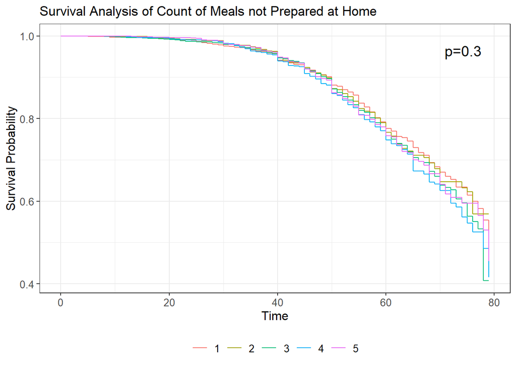

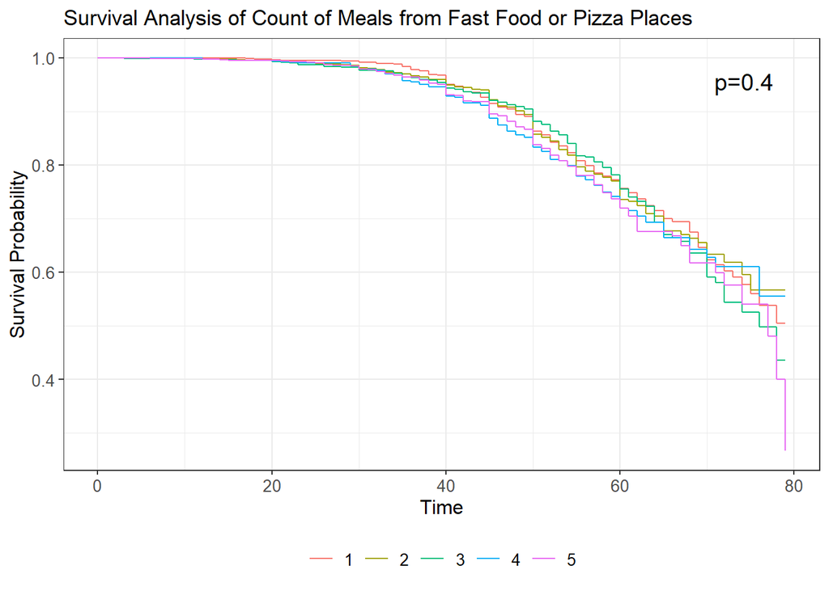

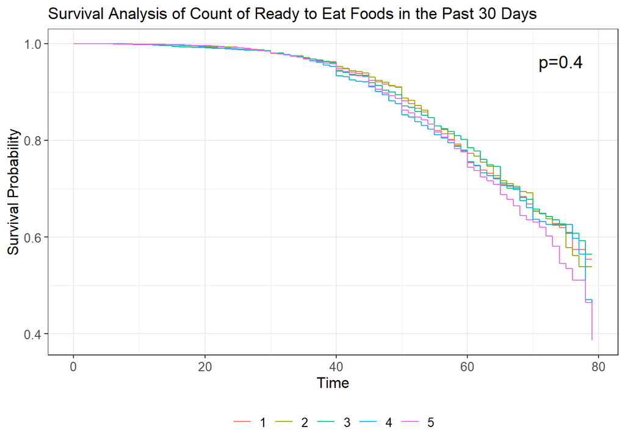

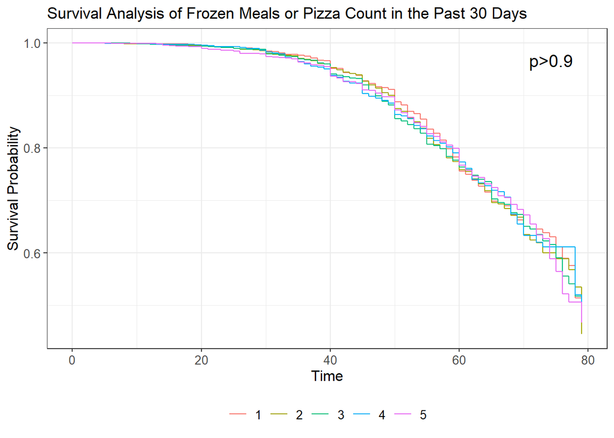

None of the continuous variables were found to have an association with the development of diabetes.